# Sympy - Symbolic algebra in Python

Load modules:

```python
%matplotlib inline
import matplotlib.pyplot as plt
```

## Introduction

There are two notable Computer Algebra Systems (CAS) for Python:

- [SymPy](http://sympy.org/en/index.html) - A python module that can be used in any Python program, or in an IPython session, that provides powerful CAS features.
- [Sage](http://www.sagemath.org/) - Sage is a full-featured and very powerful CAS enviroment that aims to provide an open source system that competes with Mathematica and Maple. Sage is not a regular Python module, but rather a CAS environment that uses Python as its programming language.

Sage is in some aspects more powerful than SymPy, but both offer very comprehensive CAS functionality. The advantage of SymPy is that it is a regular Python module and integrates well with the IPython notebook.

In this lecture we will therefore look at how to use SymPy with IPython notebooks. If you are interested in an open source CAS environment I also recommend to read more about Sage.

To get started using SymPy in a Python program or notebook, import the module `sympy`:

```python
from sympy import *
```

To get nice-looking $\LaTeX$ formatted output run:

```python
init_printing()

# or with older versions of sympy/ipython, load the IPython extension
#%load_ext sympy.interactive.ipythonprinting
# or
#%load_ext sympyprinting
```

## Symbolic variables

In SymPy we need to create symbols for the variables we want to work with. We can create a new symbol using the `Symbol` class:

```python
x = Symbol('x')
```

```python
(pi + x)**2
```

$$\left(x + \pi\right)^{2}$$

```python
# alternative way of defining symbols
a, b, c = symbols("a, b, c")
```

```python
type(a)
```

```
sympy.core.symbol.Symbol
```

We can add assumptions to symbols when we create them:

```python
x = Symbol('x', real=True)
```

```python
x.is_imaginary
```

```
False
```

```python
x = Symbol('x', positive=True)
```

```python
x > 0
```

$$\mathrm{True}$$

### Complex numbers

The imaginary unit is denoted `I` in Sympy.

```python
1+1*I
```

$$1 + i$$

```python
I**2
```

$$-1$$

```python
(x * I + 1)**2
```

$$\left(i x + 1\right)^{2}$$

### Rational numbers

There are three different numerical types in SymPy: `Real`, `Rational`, `Integer`:

```python
r1 = Rational(4,5)
r2 = Rational(5,4)
```

```python
r1
```

$$\frac{4}{5}$$

```python
r1+r2
```

$$\frac{41}{20}$$

```python
r1/r2
```

$$\frac{16}{25}$$

## Numerical evaluation

SymPy uses a library for artitrary precision as numerical backend, and has predefined SymPy expressions for a number of mathematical constants, such as: `pi`, `e`, `oo` for infinity.

To evaluate an expression numerically we can use the `evalf` function (or `N`). It takes an argument `n` which specifies the number of significant digits.

```python
pi.evalf(n=50)
```

$$3.1415926535897932384626433832795028841971693993751$$

```python
y = (x + pi)**2
```

```python
N(y, 5) # same as evalf
```

$$\left(x + 3.1416\right)^{2}$$

When we numerically evaluate algebraic expressions we often want to substitute a symbol with a numerical value. In SymPy we do that using the `subs` function:

```python
y.subs(x, 1.5)
```

$$\left(1.5 + \pi\right)^{2}$$

```python
N(y.subs(x, 1.5))
```

$$21.5443823618587$$

The `subs` function can of course also be used to substitute Symbols and expressions:

```python
y.subs(x, a+pi)
```

$$\left(a + 2 \pi\right)^{2}$$

We can also combine numerical evolution of expressions with NumPy arrays:

```python
import numpy
```

```python
x_vec = numpy.arange(0, 10, 0.1)
```

```python
y_vec = numpy.array([N(((x + pi)**2).subs(x, xx)) for xx in x_vec])
```

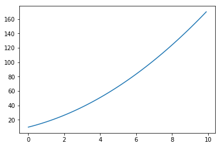

```python
fig, ax = plt.subplots()
ax.plot(x_vec, y_vec);
```

However, this kind of numerical evolution can be very slow, and there is a much more efficient way to do it: Use the function `lambdify` to "compile" a Sympy expression into a function that is much more efficient to evaluate numerically:

```python
f = lambdify([x], (x + pi)**2, 'numpy')  # the first argument is a list of variables that
                                         # f will be a function of: in this case only x -> f(x)
```

```python
y_vec = f(x_vec)  # now we can directly pass a numpy array and f(x) is efficiently evaluated
```

The speedup when using "lambdified" functions instead of direct numerical evaluation can be significant, often several orders of magnitude. Even in this simple example we get a significant speed up:

```python
%%timeit

y_vec = numpy.array([N(((x + pi)**2).subs(x, xx)) for xx in x_vec])
```

```
30.4 ms ± 2.33 ms per loop (mean ± std. dev. of 7 runs, 10 loops each)
```

```python
%%timeit

y_vec = f(x_vec)
```

```
3.53 µs ± 261 ns per loop (mean ± std. dev. of 7 runs, 100000 loops each)
```